# Report

# Разбиение набора данных на выборки

Разбил выборки в соотношении 6:2:2 (обучающая:валидационная:тестовая) потому что на валидационную и тестирующую выборки нет необходимости выделять больше данных из данного датасета для данной задачи

```python
y_name = 'In_hospital_death'
```

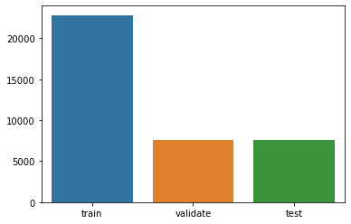

```python
train, validate, test = np.split(df.sample(frac=1), [int(.6*len(df)), int(.8*len(df))])
sns.barplot(data=pd.DataFrame([{'train': train.shape[0], 'validate': validate.shape[0], 'test': test.shape[0]}]))
```

# Выбор модели

Целевая переменная, содержит информацию умер человек в отделение интенсивной терапии (1) или нет (0)

Для такой задачи необходимо использовать алгорим классификации

Модели для выбора:

1. RandomForestClassifier
2. KNeighborsClassifier
3. CatBoostClassifier

```python
from sklearn.ensemble import RandomForestClassifier
from sklearn.neighbors import KNeighborsClassifier
from catboost import CatBoostClassifier
```

### Настройка гипер параметров

Пометил гипер параметры и примерный разброс их значений и с помощью HalvingRandomSearchCV подобрал нужные гипер параметры для моделей

```python
from sklearn.experimental import enable_halving_search_cv
from sklearn.model_selection import HalvingRandomSearchCV

from sklearn.metrics import classification_report
```

```python
X_validate = validate.drop(y_name, axis=1)
y_validate = validate[y_name]
```

```python
models = {
    'rf': RandomForestClassifier(),
    'kn': KNeighborsClassifier(),
    'cb': CatBoostClassifier()
}
```

```python
hyper_params = {
    'rf': {
        'max_depth': range(1, 10),
        'n_jobs': [-1],
        'criterion': ['gini', 'entropy']
    },
    'kn': {
        'algorithm': ['ball_tree', 'kd_tree', 'brute'],
        'n_neighbors': range(1, 10),
        'weights': ['uniform', 'distance'],
        'n_jobs': [-1]
    },
    'cb': {
        'iterations': range(500, 2000, 500),
        'silent': [True]
    }
}
```

```python
best_params = {}

for model_name in tqdm(models):
    search = HalvingRandomSearchCV(models[model_name],
                                   hyper_params[model_name],
                                   random_state=0).fit(X_validate, y_validate)
    best_params[model_name] = search.best_params_
```

```python
best_params
```

```
{'rf': {'n_jobs': -1, 'max_depth': 8, 'criterion': 'entropy'},
 'kn': {'weights': 'distance',
  'n_neighbors': 9,
  'n_jobs': -1,
  'algorithm': 'brute'},
 'cb': {'silent': True, 'iterations': 1500}}
```

## Тестирование моделей

Для тестирования и выбора модели буду использовать метрики F1-score, precision, recall, accurasy.

```python
X_train = train.drop(y_name, axis=1)
y_train = train[y_name]

X_test = test.drop(y_name, axis=1)
y_test = test[y_name]
```

```python
models = {
    'rf': RandomForestClassifier(**best_params['rf']),
    'kn': KNeighborsClassifier(**best_params['kn']),
    'cb': CatBoostClassifier(**best_params['cb'])
}
```

```python
metrics = {
    target_names[0]: [],
    target_names[1]: []
}

for model_name in tqdm(models):
    y_pred = models[model_name].fit(X_train, y_train).predict(X_test)
    report = classification_report(y_test, y_pred, target_names=target_names, output_dict=True)

    m1 = report[target_names[0]]
    m1['model'] = model_name

    m2 = report[target_names[1]]
    m2['model'] = model_name

    metrics[target_names[0]].append(m1)
    metrics[target_names[1]].append(m2)
```

```python
df_metrics_0 = pd.DataFrame(metrics[target_names[0]])
df_metrics_0 = df_metrics_0.drop('support', axis=1)
print(target_names[0])
df_metrics_0.sort_values(['precision', 'recall', 'f1-score'])
```

```
Умер
```

|  | precision | recall | f1-score | model |
| --- | --- | --- | --- | --- |
| 1 | 0.445274 | 0.160251 | 0.235681 | kn |
| 2 | 0.755274 | 0.160251 | 0.264402 | cb |
| 0 | 0.911765 | 0.027753 | 0.053866 | rf |

```python
df_metrics_1 = pd.DataFrame(metrics[target_names[1]])
df_metrics_1 = df_metrics_1.drop('support', axis=1)
print(target_names[1])
df_metrics_1.sort_values(['precision', 'recall', 'f1-score'])
```

```
Жив
```

|  | precision | recall | f1-score | model |
| --- | --- | --- | --- | --- |
| 0 | 0.856653 | 0.999538 | 0.922596 | rf |
| 1 | 0.869867 | 0.965655 | 0.915262 | kn |
| 2 | 0.872779 | 0.991067 | 0.928170 | cb |

Отсортировав по всем показателям и вывев таблицы с метриками по классам можно увидеть как определяют разные алгоритмы все классы

```python
from sklearn.metrics import accuracy_score
```

```python
metric_accuracy = {}

for model_name in tqdm(models):
    y_pred = models[model_name].fit(X_train, y_train).predict(X_test)
    metric_accuracy[model_name] = accuracy_score(y_test, y_pred)
```

```python
pd.DataFrame([{key: f'{str(metric_accuracy[key]*100)[:4]}%' for key in metric_accuracy.keys()}])
```

|  | rf | kn | cb |
| --- | --- | --- | --- |
| 0 | 85.6% | 84.7% | 86.9% |

# Сохранение модели

```python
model = RandomForestClassifier(**best_params['rf']).fit(X_train, y_train)
```

```python
with open('model_c.pkl', 'wb') as f:
    pickle.dump(model, f)
```